# Krzysztof Jankowski HW 4

## Report

### 1. Model

I trained a random forest classifier with default hyperparameters on the pc1 dataset from OpenML. I scaled the data using a StandardScaler and encoded the labels using a LabelEncoder to be in either 0 or 1. The performance of the model is presented below:

| Model | Accuracy | Precision | Recall | F1 | auc |
| --- | --- | --- | --- | --- | --- |
| RandomForestClassifier | 0.99459 | 1.0 | 0.922078 | 0.959459 | 0.999755 |

### 2. Model's predictions on 2 observations

I chose 2 observations from the dataset - one with label 1 and the other with label 0. They were sampled randomly from the dataset with a fixed seed for reproducibility purposes.

| id | loc | v(g) | ev(g) | iv(G) | N | V | L | D | I | E | B | T | lOCode | lOComment | locCodeAndComment | lOBlank | uniq_Op | uniq_Opnd | total_Op | total_Opnd | branchCount |
| --- | --- | --- | --- | --- | --- | --- | --- | --- | --- | --- | --- | --- | --- | --- | --- | --- | --- | --- | --- | --- | --- |
| 5 | 2.371091 | 2.176372 | 0.760653 | 1.668768 | 2.543026 | 2.374678 | -0.744891 | 2.297208 | 1.358303 | 1.159464 | 2.368013 | 1.159463 | 2.400672 | 2.596980 | 0.913636 | 2.623225 | 2.652350 | 2.242110 | 2.619786 | 2.423770 | 1.840141 |
| 559 | -0.435978 | -0.280374 | -0.317476 | -0.050221 | -0.387296 | -0.357574 | -0.472571 | 0.098207 | -0.663933 | -0.153018 | -0.367122 | -0.153019 | -0.430120 | -0.446667 | -0.282612 | -0.548626 | -0.404432 | -0.547307 | -0.380585 | -0.392975 | -0.276810 |

Random forest predictions Predicted classes [1 0]. Ground truth classes [1, 0].

The model correctly predicted the classes.

### 3. SHAP

#### 3.1. SHAP using Dalex

Below I present the variable attributions plots calculated with SHAP using the Dalex package. First plot corresponds to observation with label 1 and the second observation corresponds to label 0.

[figure not shown]

#### 3.2. SHAP using the shap package

Below I present the variable attributions plots calculated with SHAP using the shap package for 2 observations (one with label 1 and the other with label 0).

[output not shown]

### 4. Observations comparison

We can see that our 2 observations have different variables of the highest importance. In case of observation with label 1, the most important variables are:

- 'IOComment'
- 'IOBlank'

In case of observation with label 0, the most important variables are:

- 'uniqOpnd'
- 'E'

### 5. Different attributions for variable X

I chose the variable 'loc' and by looking at maximum and minimum value found out for which observations the 'loc' variable has a positive attribution and for the other a negative attribution. In the first observation 'loc' variable has +0.09 attribution and in the other case it has -0.04 attribution. I present the plots below:

[output not shown]

### 6. Differences in results

The results differ between 2 packages. If we look at the first couple of most important variables, the results are very similar with only difference being the precision and rounding in shap package. However when we analyze less important variables they start to differ more and sometimes even the order of them begins to differ.

### 7. SHAP for Logistic Regression.

#### 7.1. Logistic Regression performance.

I trained a Logistic Regression model with default hyperparameters. The performance of the model is presented below:

| Model | recall | precision | f1 | accuracy | auc |
| --- | --- | --- | --- | --- | --- |
| LogisticRegression | 0.142857 | 0.611111 | 0.231579 | 0.934175 | 0.865279 |

Comparing to the performance of the Random Forest, the accuracy is worse but not as much as all other metrics which are much worse. We can conclude that the Logistic Regression does not perform well on this dataset as the relationship between the features and the target variable is too complicated.

#### 7.2. SHAP for Logistic Regression

I analyzed the SHAP variable decomposition on the same 2 observations as used in RandomForest (first observation with label 1, second with label 0). The results for the LogisticRegression are different and I present them below together with previous results from RandomForest for easier comparison:

[output not shown]

We can see that in the observation with label 1 the most important variable this time is 'D' whether previously it was 'IOComment'. The second most important variable in this case is changed too.

In the case of observation with label 0 the most important variable is the same as previously but the second most important variable is different and also the attributions are different - previously we had positive and negative attributions and this time mostly negative ones.

### Task B

I calculated the Shapley values using the following formula, as it is more efficient:

$$ \phi_j = \sum_{S \subseteq P \setminus \{j\}} \frac{|S|! \cdot (|P| - |S| - 1)!}{|P|!} \cdot (v(S \cup \{j\}) - v(S)) $$

The code for calculating the Shapley values is in the appendix and the results for the following players are presented below:

- Player 'a': 25
- Player 'b': 25
- Player 'c': 50

I also double checked the results by calculating the Shapley values by hand, but even here we can perform a quick check by observing that the Shapley values correctly sum to v('abc') = 100 (efficiency) and players 'a' and 'b' have the same Shapley value (symmetry).

## Appendix

### Task A

#### Load dataset

```python
from sklearn.preprocessing import LabelEncoder, StandardScaler
from sklearn.datasets import fetch_openml
import pandas as pd

X, y = fetch_openml('pc1', return_X_y=True)
standard_scaler = StandardScaler()
standard_scaler.fit(X)
X = pd.DataFrame(standard_scaler.transform(X), columns=X.columns)

le = LabelEncoder()
y = le.fit_transform(y)

display(X.head())
display(y[:5])
print(X.shape, y.shape)
```

[output not shown]

|  | loc | v(g) | ev(g) | iv(G) | N | V | L | D | I | E | B | T | lOCode | lOComment | locCodeAndComment | lOBlank | uniq_Op | uniq_Opnd | total_Op | total_Opnd | branchCount |
| --- | --- | --- | --- | --- | --- | --- | --- | --- | --- | --- | --- | --- | --- | --- | --- | --- | --- | --- | --- | --- | --- |
| 0 | -0.631622 | -0.459046 | -0.245601 | -0.300256 | -0.588566 | -0.462872 | 7.969369 | -0.863205 | -0.893495 | -0.168975 | 2.110355 | -0.168846 | -0.608907 | -0.256439 | 0.315512 | -0.385967 | -1.480420 | -0.678168 | -0.584789 | -0.576122 | -0.494553 |
| 1 | -0.634457 | -0.503714 | -0.317476 | -0.362765 | -0.590087 | -0.463071 | 5.926964 | -0.881576 | -0.901977 | -0.168977 | 1.515760 | -0.168878 | -0.638705 | -0.351553 | 0.016450 | -0.467296 | -1.504874 | -0.685056 | -0.586581 | -0.578440 | -0.518747 |
| 2 | 1.917424 | 0.389648 | 0.041900 | -0.206493 | 1.017028 | 0.920890 | -0.608731 | 0.752212 | 1.203377 | 0.170082 | 0.921166 | 0.170082 | 1.715323 | 3.738348 | 3.007069 | 1.972589 | 1.918722 | 1.553365 | 1.124079 | 0.870503 | 0.449002 |
| 3 | 2.427800 | 1.729691 | 0.401277 | 2.293854 | 1.336423 | 1.224661 | -0.608731 | 0.794465 | 1.608220 | 0.254797 | 1.218463 | 0.254796 | 2.221885 | 3.453006 | 3.306131 | 1.403282 | 1.796451 | 1.863300 | 1.455463 | 1.171883 | 1.719172 |
| 4 | 13.656075 | 11.221663 | 6.870055 | 12.295243 | 11.263018 | 13.253154 | -0.812972 | 3.706872 | 6.775907 | 9.044464 | 13.209453 | 9.044465 | 12.949100 | 6.306425 | 14.072361 | 3.436519 | 6.198217 | 12.952091 | 11.916457 | 10.329205 | 10.186974 |

```
array([0, 1, 1, 1, 1])
```

```
(1109, 21) (1109,)
```

#### Train an tree-based ensemble model

```python
from sklearn.ensemble import RandomForestClassifier
import dalex as dx

def random_forest_predict_proba(model, df):
    return model.predict_proba(df)[:, 1]

random_forest = RandomForestClassifier(random_state=42, n_jobs=-1)
random_forest.fit(X, y)
explainer = dx.Explainer(random_forest, X, y, predict_function=random_forest_predict_proba)
explainer.model_performance()
```

[output not shown]

```
X does not have valid feature names, but RandomForestClassifier was fitted with feature names
```

|  | recall | precision | f1 | accuracy | auc |
| --- | --- | --- | --- | --- | --- |
| RandomForestClassifier | 0.922078 | 1.0 | 0.959459 | 0.99459 | 0.999755 |

#### Model's predictions on 2 observations

```python
import pandas as pd
import numpy as np

# set seed for reproducibility
pd.set_option('display.max_columns', None)
np.random.seed(42)
num_of_sampled_observations = 1

observations_with_target_true = X[y == 1]
observations_with_target_false = X[y == 0]

# sample 2 observations randomly from each class
labels = [1, 0]
sampled_observations = pd.concat([observations_with_target_true.sample(num_of_sampled_observations),
                                  observations_with_target_false.sample(num_of_sampled_observations)])
display(sampled_observations)

print(f'Random forest predictions')
print(f'Predicted classes {random_forest.predict(sampled_observations)}.')
print(f'Ground truth classes {num_of_sampled_observations * [1] + num_of_sampled_observations * [0]}.')
```

|  | loc | v(g) | ev(g) | iv(G) | N | V | L | D | I | E | B | T | lOCode | lOComment | locCodeAndComment | lOBlank | uniq_Op | uniq_Opnd | total_Op | total_Opnd | branchCount |
| --- | --- | --- | --- | --- | --- | --- | --- | --- | --- | --- | --- | --- | --- | --- | --- | --- | --- | --- | --- | --- | --- |
| 5 | 2.371091 | 2.176372 | 0.760653 | 1.668768 | 2.543026 | 2.374678 | -0.744891 | 2.297208 | 1.358303 | 1.159464 | 2.368013 | 1.159463 | 2.400672 | 2.596980 | 0.913636 | 2.623225 | 2.652350 | 2.242110 | 2.619786 | 2.423770 | 1.840141 |
| 559 | -0.435978 | -0.280374 | -0.317476 | -0.050221 | -0.387296 | -0.357574 | -0.472571 | 0.098207 | -0.663933 | -0.153018 | -0.367122 | -0.153019 | -0.430120 | -0.446667 | -0.282612 | -0.548626 | -0.404432 | -0.547307 | -0.380585 | -0.392975 | -0.276810 |

```
Random forest predictions
Predicted classes [1 0].
Ground truth classes [1, 0].
```

#### Calculate Shapley values

```python
shap_attributions = [explainer.predict_parts(sampled_observations.iloc[i], type="shap", label=f'Observation with label {labels[i]}') for i in
                     range(len(sampled_observations))]
```

```python
shap_attributions[0].plot(shap_attributions[1::])
```

[interactive chart not shown]

```python
import shap
shap_explainer = shap.TreeExplainer(random_forest, X, model_output='probability')
```

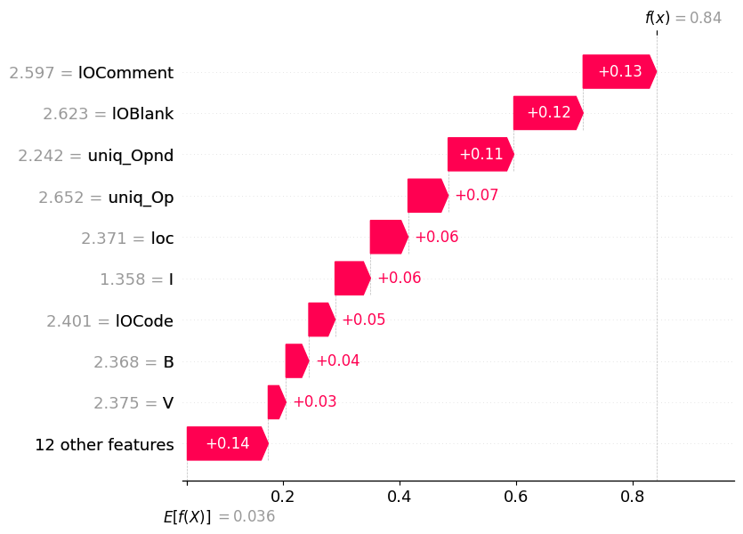

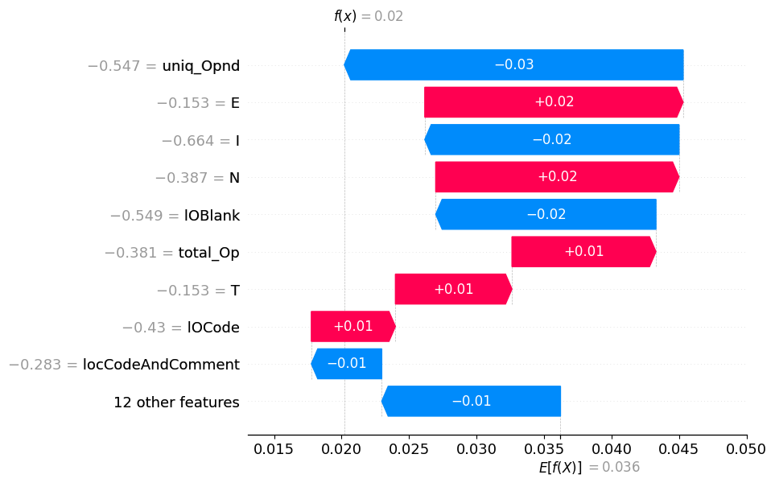

```python
shap_values = shap_explainer(sampled_observations)
for i in range(len(sampled_observations)):
    shap.plots.waterfall(shap_values[i, :, 1])
```

#### Different attributions for variable X

```python
all_shap_values = shap_explainer(X)
```

```
 96%|=================== | 2124/2218 [00:21<00:00]
```

```
0.09316881248214486
-0.03583401970095565
```

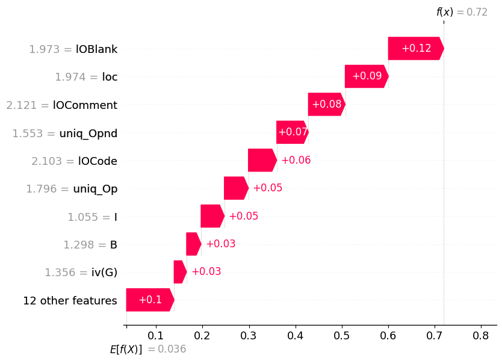

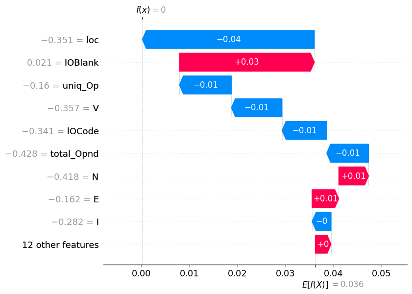

```python
max_index = all_shap_values[:, 0, 1].values.argmax()
min_index = all_shap_values[:, 0, 1].values.argmin()
print(all_shap_values[:, 0, 1].values.max())
print(all_shap_values[:, 0, 1].values.min())
min_max_shap_values = shap_explainer(X.iloc[[max_index, min_index]])
for i in range(2):
    shap.plots.waterfall(min_max_shap_values[i, :, 1])
```

#### SHAP for Logistic Regression

```python
from sklearn.linear_model import LogisticRegression

def linear_model_predict_proba(model, df):
    return model.predict_proba(df)[:, 1]

linear_model = LogisticRegression(random_state=42, n_jobs=-1)
linear_model.fit(X, y)

linear_explainer = dx.Explainer(linear_model, X, y, predict_function=linear_model_predict_proba)
linear_explainer.model_performance()
```

[output not shown]

```
X does not have valid feature names, but LogisticRegression was fitted with feature names
```

|  | recall | precision | f1 | accuracy | auc |
| --- | --- | --- | --- | --- | --- |
| LogisticRegression | 0.142857 | 0.611111 | 0.231579 | 0.934175 | 0.865279 |

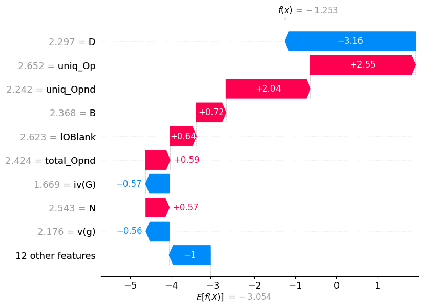

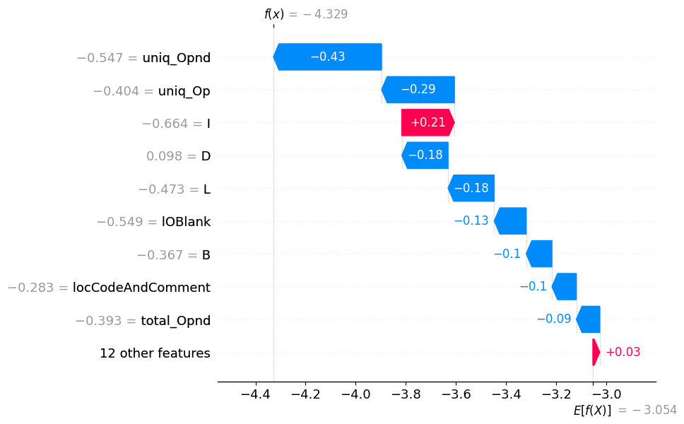

```python
shap_linear_explainer = shap.Explainer(linear_model, X, model_output='probability')
shap_linear_values = shap_linear_explainer(sampled_observations)
for i in range(len(sampled_observations)):
    shap.plots.waterfall(shap_linear_values[i])
```

### Task B

```python
def generate_subsets(lst):
    """
    Generator function yielding all subsets of a given list (including the empty subset).
    :param lst: List of elements
    :return: Generator yielding all subsets of the given list
    """

    def generate_subset_recursive(current_subset, index):
        """
        Recursive function that generates all subsets of a given list (including the empty subset).
        :param current_subset: Current subset
        :param index: Current index in the list
        :return: Generator yielding all subsets of the given list
        """
        if index == len(lst):
            yield current_subset
            return

        # Include the current element in the subset
        yield from generate_subset_recursive(current_subset + lst[index], index + 1)

        # Exclude the current element from the subset
        yield from generate_subset_recursive(current_subset, index + 1)

    yield from generate_subset_recursive('', 0)
```

```python
import math
from typing import Dict, List


def calculate_shapley_value(player_id: str, players_ids: List[str], coalitions_dict: Dict[str, int]) -> float:
    """
    Calculates the Shapley value for each player in a game with the given coalitions and their values.
    :param player_id: id of the player for which the Shapley value should be calculated
    :param players_ids: list of players ids
    :param coalitions_dict: dictionary of coalitions and their values (ids must be sorted)

    :return: shepley value for the player with the given id
    """
    subset_players_ids = players_ids.copy()
    subset_players_ids.remove(player_id)

    P = len(players_ids)
    P_factorial = math.factorial(P)

    shapley_value = 0
    for coalition in generate_subsets(subset_players_ids):
        S = len(coalition)
        previous_coalition_value = coalitions_dict[coalition]
        current_coalition_value = coalitions_dict[''.join(sorted(coalition + player_id))]
        shapley_value += (current_coalition_value - previous_coalition_value) * math.factorial(S) \
                         * math.factorial(P - S - 1)

    return shapley_value / P_factorial
```

```python
players_ids = ['a', 'b', 'c']
coalitions_dict = {
    '': 0,
    'a': 20,
    'b': 20,
    'c': 60,
    'ab': 60,
    'ac': 70,
    'bc': 70,
    'abc': 100
}
for players_id in players_ids:
    shapley_value = calculate_shapley_value(players_id, players_ids, coalitions_dict)
    print(f'Shapley value for player {players_id}: {shapley_value}')
```

```
Shapley value for player a: 25.0
Shapley value for player b: 25.0
Shapley value for player c: 50.0
```